# Assignment 2

2021-10-23

## Introduction

In this exercise, three datasets were interrogated for statistical significance. The first dataset was heart rate and blood pressure, where a correlation analysis was done. The second dataset was hours of sleep obtained by participants receiving a drug or placebo control. The final dataset was birthweights of babies from mothers with different smoking habits.

## Method

The data for these questions were provided by the exercise prompt for the course, which were in turn obtained from Reference 1 (Ennos 2007).

In most cases, custom functions were used to tabulate and organize statistical test results in a structured manner that would render well in a knit markdown document.

### Creating the custom functions that will be used

```r
# Scales a vector to have mean = 0 and sd = 1
scale_this <- function(x){
  (x - mean(x, na.rm = TRUE)) / sd(x, na.rm = TRUE)
}

# Tabulates descriptive statistics for interval/ratio data in a nice format
descNum <- function(ds, vector, vectorInPlainEnglish, title = '', subtitle = ''
                 , buildGtDirectly = TRUE) {
    results <- ds %>%
        summarize(
            Parameter = paste({{vectorInPlainEnglish}})
            , `Mean` = mean({{vector}})
            , SD = sd({{vector}})
            , Median = median({{vector}}))

    if (buildGtDirectly == F) results
    else if (buildGtDirectly == T) {
        results %>%
            gt() %>%
            tab_header(
                title = title , subtitle = subtitle
            ) %>%
            fmt_number(columns = c(Mean, SD, Median))
    }
}

# Tabulates results from Shapiro-Wilk tests in a nice format
tabSwResults <- function(testVector, vectorPlainEnglish
                         , title = '', subtitle = ''
                         , buildGtDirectly = TRUE
                         , alpha = .05) {
    localVar <- shapiro.test(testVector)

    results <-
        data.frame(
            Data = vectorPlainEnglish
            , Method = localVar$method
            , W = localVar$statistic
            , p = localVar$p.value
        ) %>%
        mutate(
            Interpretation =
                case_when(
                    p < alpha ~ 'Significantly different than normal distribution'
                    , p >= alpha ~
                        'Not significantly different than normal distribution'
                )
        )

    rownames(results) <- NULL

    if (buildGtDirectly == F) results
    else if (buildGtDirectly == T) {
        results %>%
            gt() %>%
            tab_header(
                title = title
                , subtitle = subtitle
            ) %>%
            fmt_number(columns = c(W)) %>%
            fmt_scientific(columns = c(p))
    }
}

# Tabulates correlation results in a nice format
tabCorResults <- function(testVector1, testVector2
                          , formulaInPlainEnglish
                          , title = '', subtitle = ''
                          , buildGtDirectly = TRUE
                          , alternative = 'two.sided', method = 'kendall'
                          , alpha = .05) {

    localVar <- cor.test(
        testVector1
        , testVector2
        , alternative = alternative
        , method = method)

    localStat <- names(localVar$statistic)
    localEstimate <- names(localVar$estimate)

    results <-
        data.frame(
            Data = formulaInPlainEnglish
            , Method = localVar$method
            , Version = localVar$alternative
            , stat = localVar$statistic
            , df = length(testVector1) - 2
            , estimate = localVar$estimate
            , p = localVar$p.value
        ) %>%
        mutate(
            Interpretation =
                case_when(
                    p < alpha ~ 'Significant correlation'
                    , p >= alpha ~
                        'Non-significant correlation'
                )
        ) %>%
        rename( {{localStat}} := stat
                , {{localEstimate}} := estimate)

    rownames(results) <- NULL
    if (buildGtDirectly == F) results
    else if (buildGtDirectly == T) {
        results %>%
            gt() %>%
            tab_header(
                title = title
                , subtitle = subtitle
            ) %>%
            fmt_scientific(columns = c({{localStat}}, {{localEstimate}}, p))
    }
}

# Standardizes two vectors to mean = 0 and sd = 1 and plots against random sample of equal n from a normal distribution
pltStdzdRidges <-
    function(dataset, testVector1, testVector2,
             testVector1InPlainEnglish, testVector2InPlainEnglish) {
    dataset %>%
      mutate(
        `tV1 standardized` = scale_this(testVector1)
        , `tV2 standardized` = scale_this(testVector2)
        , `Random Sample from a Normal Distribution` = rnorm(n())
        ) %>%
    select(`tV1 standardized`
           , `tV2 standardized`
           , `Random Sample from a Normal Distribution`
           ) %>%
    pivot_longer(
        cols = c(
            `tV1 standardized`
            , `tV2 standardized`
            , `Random Sample from a Normal Distribution`
            )
        , names_to = 'Variables', values_to = 'Standardized values') %>%
    mutate(
        Variables =
            case_when(Variables == 'tV1 standardized' ~
                          paste0(testVector1InPlainEnglish, ', Standardized')
                      , Variables == 'tV2 standardized' ~
                          paste0(testVector2InPlainEnglish, ', Standardized')
                      , TRUE ~ Variables)
    ) %>%
    ggplot(aes(`Standardized values`, Variables, fill = Variables)) +
    geom_density_ridges() +
    theme(legend.position = 'none') +
  ylab('')
    }

# Tabulates results from a t-test in a nice format

# This function will need to be modified if one wants to tabulate results
# from other versions of the t-test (e.g., one-sided, paired, equal-variance)
#
# Also be aware that this function makes a huge presumption about how data is sorted in the case
# of paired t-tests! Specifically, the t.test call does not permit use of | to specify a
# grouping variable, and thus, the t.test call presumes your data are already sorted by that
# variable that has no place in the t.test call!

tabTtestResults <- function(formula
                            , formulaInPlainEnglish
                            , title = '', subtitle = ''
                            , buildGtDirectly = TRUE
                            , alternative = 'two.sided'
                            , paired = FALSE
                            , var.equal = FALSE , alpha = .05) {

    # Do unpaired t-test first regardless in order to extract group means (not in object if paired)
    localVar <- t.test(formula
                       , alternative = alternative, paired = FALSE
                       , var.equal = var.equal, conf.level = (1 - alpha))

    localMeans <-
        localVar$estimate %>%
        enframe() %>%
        mutate(name = str_replace(name, 'mean in group', 'Mean for ')) %>%
        pivot_wider()

    # Now that have means, run paired t-test if specified necessary
    if (paired == TRUE) {
        localVar <- t.test(formula
                   , alternative = alternative, paired = paired
                   , var.equal = var.equal, conf.level = (1 - alpha))
    }

    results <-
        data.frame(
            Data = formulaInPlainEnglish
            , Method = localVar$method
            , Alternative = localVar$alternative
            , t = abs(localVar$statistic)
            , df = localVar$parameter
            , p = localVar$p.value
            , lowCI =
                min(localVar$conf.int[1], localVar$conf.int[2])
            , uppCI =
                max(localVar$conf.int[1], localVar$conf.int[2])
        ) %>%
        mutate(
            Interpretation =
                case_when(
                    p < alpha ~ 'Significant difference in means'
                    , p >= alpha ~
                        'Non-significant difference in means'
                )
        ) %>%
        cbind(localMeans) %>%
        rename(`Mean difference, lower end of CI` = lowCI
               , `Mean difference, upper end of CI` = uppCI)

    rownames(results) <- NULL
    if (buildGtDirectly == F) results
    else if (buildGtDirectly == T) {
        results %>%
            gt() %>%
            tab_header(
                title = title
                , subtitle = subtitle
            ) %>%
            fmt_number(columns = c(t, df
                                   , `Mean difference, lower end of CI`
                                   , `Mean difference, upper end of CI`
                                   , 10, 11)) %>%
            fmt_scientific(columns = c(p))
    }
}
```

## Results

### Step 1: Correlating heart rate and blood pressure

#### Instructions:

Statistical data should be reported in the form: Mean ± SD and Median.

```r
library(gt)
rbind(
descNum(hrBp, Heart.rate, 'Heart rate', buildGtDirectly = FALSE)
, descNum(hrBp, Blood.pressure, 'Blood pressure', buildGtDirectly = FALSE)
) %>%
    gt() %>%
    tab_header('Table 1', 'Descriptive Statistics for Heart Rate and Blood Pressure') %>%
    fmt_engineering(columns = c(Mean, SD, Median))
```

Table 1

Descriptive Statistics for Heart Rate and Blood Pressure

| Parameter | Mean | SD | Median |
| --- | --- | --- | --- |
| Heart rate | 70.60 | 10.31 | 69.50 |
| Blood pressure | 178.13 | 17.02 | 175.50 |

#### Instructions:

Make a box plot for each variable.

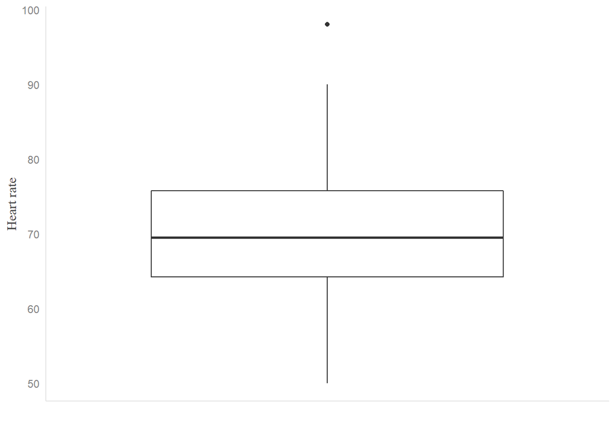

Figure 1: Boxplot for heart rate

```r
hrBp %>%
    ggplot(aes(x = '', Heart.rate)) +
    geom_boxplot() +
    xlab('') + ylab('Heart rate') +
    theme(legend.position = 'none')
```

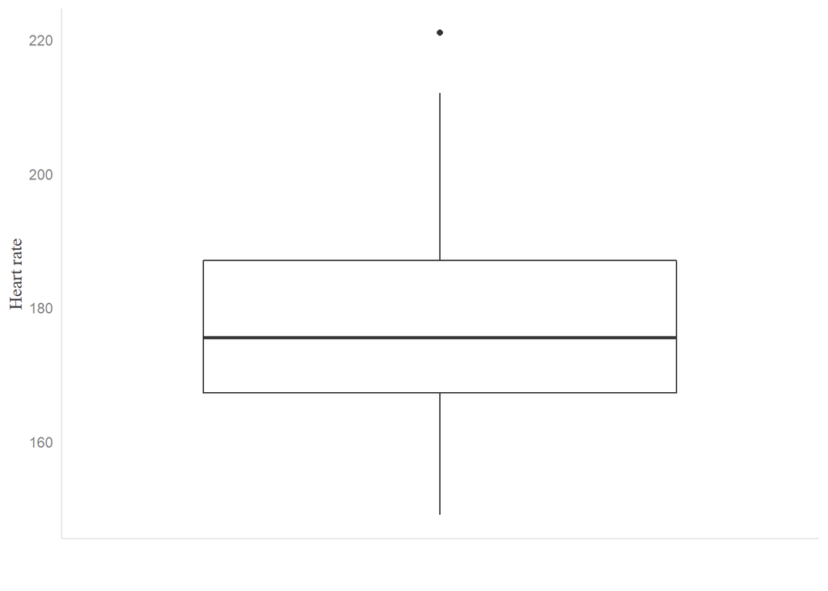

Figure 2: Boxplot for Blood pressure

```r
hrBp %>%
    ggplot(aes(x = '', Blood.pressure)) +
    geom_boxplot() +
    xlab('') + ylab('Heart rate') +
    theme(legend.position = 'none')
```

#### Instructions:

What does the box plot show?

##### Answer:

The box plots show the dispersion of values within the variable. Specifically, the center line shows the median, the edges of the boxes show the 25th- 75th percentiles, and the ends of the whiskers extend beyond the 25th and 75th percentiles by 1.5 * the interquartile range (IQR). Any dots that lay beyond the whiskers are data points that lay outside of these values and are outliers.

#### Instructions:

Try to make a plot where you can view if the variables are approximately normally distributed.

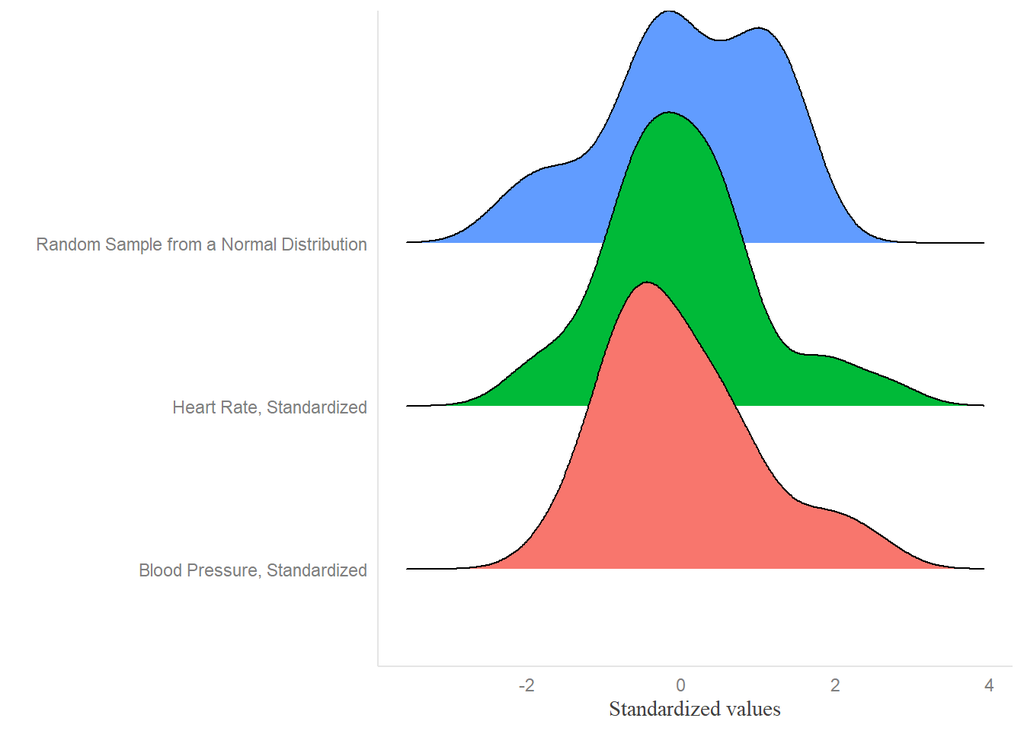

Figure 3: Kernel-density estimates of standardized HR and BP along with a randomly-generated sample from a normal distribution

```r
set.seed(421)
library(ggridges)
pltStdzdRidges(hrBp, hrBp$Heart.rate, hrBp$Blood.pressure, 'Heart Rate', 'Blood Pressure')
```

```r
rbind(
  tabSwResults(hrBp$Heart.rate, 'Heart Rate', buildGtDirectly = F)
  , tabSwResults(hrBp$Blood.pressure, 'Blood Pressure', buildGtDirectly = F)
  ) %>%
  gt() %>%
  tab_header(
    title = 'Table 2'
    , subtitle =
      'Results from Shapiro-Wilk normality tests on Heart Rate and Blood Pressure'
    ) %>%
  fmt_number(columns = c(W)) %>%
  fmt_scientific(columns = c(p))
```

Table 2

Results from Shapiro-Wilk normality tests on Heart Rate and Blood Pressure

| Data | Method | W | p | Interpretation |
| --- | --- | --- | --- | --- |
| Heart Rate | Shapiro-Wilk normality test | 0.96 | 3.89 × 10<sup>−1</sup> | Not significantly different than normal distribution |
| Blood Pressure | Shapiro-Wilk normality test | 0.95 | 1.81 × 10<sup>−1</sup> | Not significantly different than normal distribution |

#### Instructions:

Is there a correlation between heart rate and blood pressure? Make a proper analysis and show the results as statistic values in the form: correlation coefficient, df, p–value, name of test. Also, make a diagram with Blood pressure as x-variable and Hart rate as y-variable. Use Scatterplot.

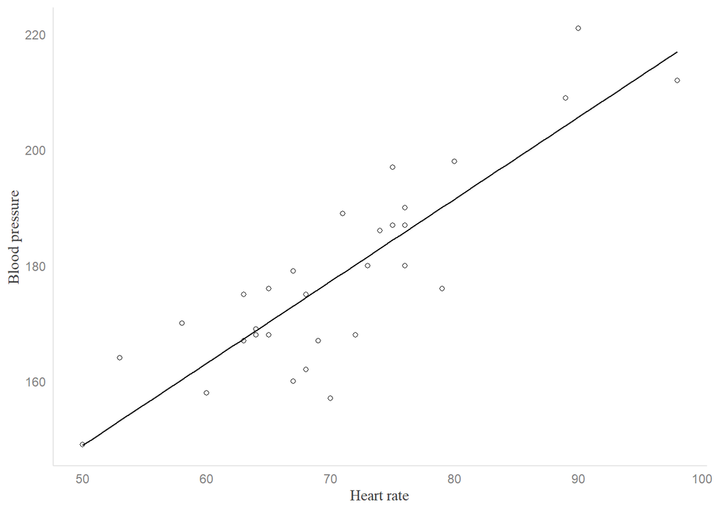

Figure 4: Correlation between Heart Rate and Blood Pressure

```r
hrBp %>%
  ggplot(aes(x = Heart.rate, y = Blood.pressure)) +
    geom_point(shape = 21) +
    geom_smooth(method = lm, se = F, color = 'black', size = 0.5) +
    theme(legend.position = 'none') +
  ylab('Blood pressure') +
  xlab('Heart rate')
```

```r
tabCorResults(hrBp$Heart.rate, hrBp$Blood.pressure, 'Blood Pressure as it relates to Heart Rate', 'Table 3', 'Correlation analysis for blood pressure and heart rate', method = 'pearson')
```

Table 3

Correlation analysis for blood pressure and heart rate

| Data | Method | Version | t | df | cor | p | Interpretation |
| --- | --- | --- | --- | --- | --- | --- | --- |
| Blood Pressure as it relates to Heart Rate | Pearson's product-moment correlation | two.sided | 8.90 | 28 | 8.60 × 10<sup>−1</sup> | 1.18 × 10<sup>−9</sup> | Significant correlation |

### Step 2: Examining the effects of a drug on sleep duration

#### Instructions:

What type of t-test would be best to use for an analysis of this experiment. Explain why the statistical test you used will be the best option given this experimental design

##### Answer:

A paired-t test would be best for this kind of experiment since the same research subjects contribute data in both experimental conditions.

```r
sleep %<>%
    mutate(`Difference in hours` = Drug - Placebo
           , `Second random sample from normal distribution` = rnorm(n()))

tabSwResults(sleep$`Difference in hours`, 'Paired difference in hours between treatments', 'Table 4', 'Normality test for paired differences between treatments')
```

Table 4

Normality test for paired differences between treatments

| Data | Method | W | p | Interpretation |
| --- | --- | --- | --- | --- |
| Paired difference in hours between treatments | Shapiro-Wilk normality test | 0.92 | 3.44 × 10<sup>−1</sup> | Not significantly different than normal distribution |

#### Instructions:

Present the result as statistics in the form: t-value, df, p-value, type of test.

```r
sleepLong <-
    sleep %>%
    pivot_longer(cols = c(Drug, Placebo), names_to = 'Treatment', values_to = 'Hours of sleep')

tabTtestResults(sleepLong$`Hours of sleep` ~ sleepLong$Treatment, 'Hours of sleep by Treatment', 'Table 5', 'T-test results comparing average hours of sleep between drug and placebo-treated groups', paired = TRUE)
```

Table 5

T-test results comparing average hours of sleep between drug and placebo-treated groups

| Data | Method | Alternative | t | df | p | Mean difference, lower end of CI | Mean difference, upper end of CI | Interpretation | Mean for Drug | Mean for Placebo |
| --- | --- | --- | --- | --- | --- | --- | --- | --- | --- | --- |
| Hours of sleep by Treatment | Paired t-test | two.sided | 1.48 | 9.00 | 1.73 × 10<sup>−1</sup> | −0.57 | 2.73 | Non-significant difference in means | 6.66 | 5.58 |

#### Instructions:

Also make a graph displaying the central tendency and the spread.

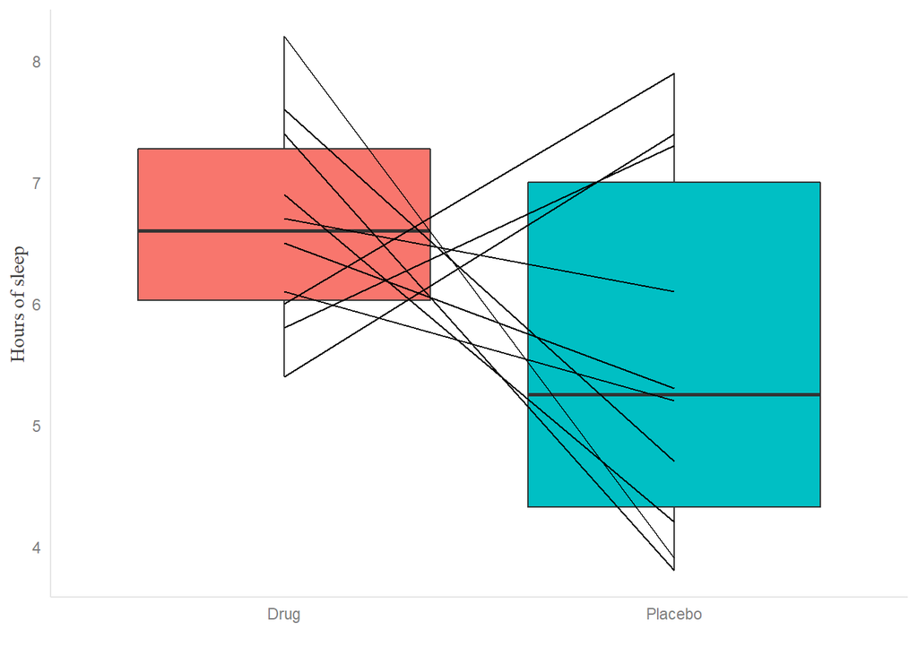

Figure 6: Boxplot for Hours of Sleep by treatment with lines showing individual subject responses in both conditions.

```r
sleepLong %>%
    mutate(Subject = as.factor(Subject)) %>%
    ggplot(aes(x = Treatment, `Hours of sleep`, fill = Treatment)) +
    geom_boxplot() +
    geom_line(aes(group = Subject)) +
    xlab('') + ylab('Hours of sleep') +
    guides(fill = F)
```

### Step 3: Examining the relationship between mother’s smoking habits and baby birth weight

#### Instructions:

```r
bwSmoke <-
  bwBySmoke %>%
      filter(Smoking.habit == 'Heavy smokers') %>%
      select(Birth.weight)

bwNonSmoke <-
  bwBySmoke %>%
      filter(Smoking.habit == 'Non-smokers') %>%
      select(Birth.weight)

rbind(
  tabSwResults(
    bwSmoke$Birth.weight
    , 'Birth weight of babies from mothers that are heavy smokers'
    , buildGtDirectly = F)
  ,   tabSwResults(
    bwNonSmoke$Birth.weight
    , 'Birth weight of babies from mothers that are non-smokers'
    , buildGtDirectly = F)
  ) %>%
  gt() %>%
  tab_header(
    title = 'Table 6'
    , subtitle =
      "Results from Shapiro-Wilk normality tests on Birth Weights based on Mother's smoking habit"
    ) %>%
  fmt_number(columns = c(W)) %>%
  fmt_scientific(columns = c(p))
```

Table 6

Results from Shapiro-Wilk normality tests on Birth Weights based on Mother's smoking habit

| Data | Method | W | p | Interpretation |
| --- | --- | --- | --- | --- |
| Birth weight of babies from mothers that are heavy smokers | Shapiro-Wilk normality test | 0.69 | 2.40 × 10<sup>−6</sup> | Significantly different than normal distribution |
| Birth weight of babies from mothers that are non-smokers | Shapiro-Wilk normality test | 0.79 | 4.14 × 10<sup>−5</sup> | Significantly different than normal distribution |

```r
tabTtestResults(bwBySmoke$Birth.weight ~ bwBySmoke$Smoking.habit, "Birth weight by Mother's smoking status", 'Table 7', 'T-test results comparing birth weights of babies from mothers with different smokint habits', paired = FALSE)
```

Table 7

T-test results comparing birth weights of babies from mothers with different smokint habits

| Data | Method | Alternative | t | df | p | Mean difference, lower end of CI | Mean difference, upper end of CI | Interpretation | Mean for Heavy smokers | Mean for Non-smokers |
| --- | --- | --- | --- | --- | --- | --- | --- | --- | --- | --- |
| Birth weight by Mother's smoking status | Welch Two Sample t-test | two.sided | 0.63 | 55.54 | 5.30 × 10<sup>−1</sup> | −20.46 | 10.64 | Non-significant difference in means | 21.86 | 26.77 |

## Discussion

There is a significant correlation between heart rate and blood pressure, as detected by the Pearson Product-Moment Correlation method; as one variable increases, the other also tends to increase.

There was no statistically significant effect of the drug investigated in *step 2* of this assignment on sleep duration; the paired t-test was non-significant.

## References

1. Ennos R 2007. Statistical and data handling skills in biology. 2nd ed. Pearson Ed. Ltd, Harlow, England
2. [`scale_this` function from Stack Overflow](https://stackoverflow.com/questions/35775696/trying-to-use-dplyr-to-group-by-and-apply-scale)